# Customer Service Requests Analysis

## Project 1 $\color{Coral}{\text{Customer Service Requests Analysis}}$ Dataset : 311_Service_Requests_from_2010_to_Present Python libraries used : NumPy, Pandas, Matplotlib, Seabrom, SciPy and DateTime. *Name of the contributer : Rajeev Vhanhuve*

### Solution :

```python
# importing required libraries
import numpy as np
import pandas as pd
import matplotlib.pyplot as plt
from matplotlib import style
%matplotlib inline
import seaborn as sns

from scipy.stats import chi2_contingency
from scipy.stats import chi2
```

##### 1. Importing a 311 NYC service request.

```python
# Note: Our Dataset is very large so setting low_memory to false
df = pd.read_csv('311_Service_Requests_from_2010_to_Present.csv', low_memory = False)
```

```python
# View the top 5 elements of the dataset
df.head()
```

|  | Unique Key | Created Date | Closed Date | Agency | Agency Name | Complaint Type | Descriptor | Location Type | Incident Zip | Incident Address | ... | Bridge Highway Name | Bridge Highway Direction | Road Ramp | Bridge Highway Segment | Garage Lot Name | Ferry Direction | Ferry Terminal Name | Latitude | Longitude | Location |
| --- | --- | --- | --- | --- | --- | --- | --- | --- | --- | --- | --- | --- | --- | --- | --- | --- | --- | --- | --- | --- | --- |
| 0 | 32310363 | 12/31/2015 11:59:45 PM | 01-01-16 0:55 | NYPD | New York City Police Department | Noise - Street/Sidewalk | Loud Music/Party | Street/Sidewalk | 10034.0 | 71 VERMILYEA AVENUE | ... | NaN | NaN | NaN | NaN | NaN | NaN | NaN | 40.865682 | -73.923501 | (40.86568153633767, -73.92350095571744) |
| 1 | 32309934 | 12/31/2015 11:59:44 PM | 01-01-16 1:26 | NYPD | New York City Police Department | Blocked Driveway | No Access | Street/Sidewalk | 11105.0 | 27-07 23 AVENUE | ... | NaN | NaN | NaN | NaN | NaN | NaN | NaN | 40.775945 | -73.915094 | (40.775945312321085, -73.91509393898605) |
| 2 | 32309159 | 12/31/2015 11:59:29 PM | 01-01-16 4:51 | NYPD | New York City Police Department | Blocked Driveway | No Access | Street/Sidewalk | 10458.0 | 2897 VALENTINE AVENUE | ... | NaN | NaN | NaN | NaN | NaN | NaN | NaN | 40.870325 | -73.888525 | (40.870324522111424, -73.88852464418646) |
| 3 | 32305098 | 12/31/2015 11:57:46 PM | 01-01-16 7:43 | NYPD | New York City Police Department | Illegal Parking | Commercial Overnight Parking | Street/Sidewalk | 10461.0 | 2940 BAISLEY AVENUE | ... | NaN | NaN | NaN | NaN | NaN | NaN | NaN | 40.835994 | -73.828379 | (40.83599404683083, -73.82837939584206) |
| 4 | 32306529 | 12/31/2015 11:56:58 PM | 01-01-16 3:24 | NYPD | New York City Police Department | Illegal Parking | Blocked Sidewalk | Street/Sidewalk | 11373.0 | 87-14 57 ROAD | ... | NaN | NaN | NaN | NaN | NaN | NaN | NaN | 40.733060 | -73.874170 | (40.733059618956815, -73.87416975810375) |

5 rows × 53 columns

```python
# shape of the dataset
df.shape
```

```
(300698, 53)
```

```python
df.info()
```

```
<class 'pandas.core.frame.DataFrame'>
RangeIndex: 300698 entries, 0 to 300697
Data columns (total 53 columns):
 #   Column                          Non-Null Count   Dtype
---  ------                          --------------   -----
 0   Unique Key                      300698 non-null  int64
 1   Created Date                    300698 non-null  object
 2   Closed Date                     298534 non-null  object
 3   Agency                          300698 non-null  object
 4   Agency Name                     300698 non-null  object
 5   Complaint Type                  300698 non-null  object
 6   Descriptor                      294784 non-null  object
 7   Location Type                   300567 non-null  object
 8   Incident Zip                    298083 non-null  float64
 9   Incident Address                256288 non-null  object
```

[output cut: 45 more lines]

```python
# viewing the columns
df.columns
```

```
Index(['Unique Key', 'Created Date', 'Closed Date', 'Agency', 'Agency Name',
       'Complaint Type', 'Descriptor', 'Location Type', 'Incident Zip',
       'Incident Address', 'Street Name', 'Cross Street 1', 'Cross Street 2',
       'Intersection Street 1', 'Intersection Street 2', 'Address Type',
       'City', 'Landmark', 'Facility Type', 'Status', 'Due Date',
       'Resolution Description', 'Resolution Action Updated Date',
       'Community Board', 'Borough', 'X Coordinate (State Plane)',
       'Y Coordinate (State Plane)', 'Park Facility Name', 'Park Borough',
       'School Name', 'School Number', 'School Region', 'School Code',
       'School Phone Number', 'School Address', 'School City', 'School State',
       'School Zip', 'School Not Found', 'School or Citywide Complaint',
       'Vehicle Type', 'Taxi Company Borough', 'Taxi Pick Up Location',
       'Bridge Highway Name', 'Bridge Highway Direction', 'Road Ramp',
       'Bridge Highway Segment', 'Garage Lot Name', 'Ferry Direction',
       'Ferry Terminal Name', 'Latitude', 'Longitude', 'Location'],
      dtype='object')
```

```python
#There are a lots of columns in our dataset but I don't need all of them. So I will drop the columns that have a very large number
#of null values in it. Also I don't need the unnecessary columns, so I will drop them.
drop_columns = ['Agency Name','Incident Address','Street Name','Cross Street 1','Cross Street 2','Intersection Street 1',
'Intersection Street 2','Address Type','Park Facility Name','Park Borough','School Name','School Number','School Region',
'School Code','School Phone Number','School Address','School City','School State','School Zip','School Not Found',
'School or Citywide Complaint','Vehicle Type','Taxi Company Borough','Taxi Pick Up Location','Bridge Highway Name',
'Bridge Highway Direction','Road Ramp','Bridge Highway Segment','Garage Lot Name','Ferry Direction',
'Ferry Terminal Name','Landmark','X Coordinate (State Plane)','Y Coordinate (State Plane)','Due Date',
'Resolution Action Updated Date','Community Board','Facility Type','Location']
df = df.drop(drop_columns, axis=1)
```

```python
# Checking the shape of Dataset.
df.shape
#So we are upto 14 columns from 53...
```

```
(300698, 14)
```

```python
# Now check for null values, data type of the columns etc.
# checking the info of the dataset
df.info()
```

```
<class 'pandas.core.frame.DataFrame'>
RangeIndex: 300698 entries, 0 to 300697
Data columns (total 14 columns):
 #   Column                  Non-Null Count   Dtype
---  ------                  --------------   -----
 0   Unique Key              300698 non-null  int64
 1   Created Date            300698 non-null  object
 2   Closed Date             298534 non-null  object
 3   Agency                  300698 non-null  object
 4   Complaint Type          300698 non-null  object
 5   Descriptor              294784 non-null  object
 6   Location Type           300567 non-null  object
 7   Incident Zip            298083 non-null  float64
 8   City                    298084 non-null  object
 9   Status                  300698 non-null  object
 10  Resolution Description  300698 non-null  object
 11  Borough                 300698 non-null  object
 12  Latitude                297158 non-null  float64
 13  Longitude               297158 non-null  float64
dtypes: float64(3), int64(1), object(10)
memory usage: 32.1+ MB
```

```python
# checking the number of null values in the columns
df.isnull().sum()
```

```
Unique Key                   0
Created Date                 0
Closed Date               2164
Agency                       0
Complaint Type               0
Descriptor                5914
Location Type              131
Incident Zip              2615
City                      2614
Status                       0
Resolution Description       0
Borough                      0
Latitude                  3540
Longitude                 3540
dtype: int64
```

```python
# To eliminate the null values choosing the closed cases only
df = df[df['Status'] == 'Closed']
df.isnull().sum()
```

```
Unique Key                   0
Created Date                 0
Closed Date                  0
Agency                       0
Complaint Type               0
Descriptor                5903
Location Type               65
Incident Zip               507
City                       506
Status                       0
Resolution Description       0
Borough                      0
Latitude                  1432
Longitude                 1432
dtype: int64
```

```python
# Since all the cases are of closed cases we can now drop the column Status
df = df.drop(['Status'], axis = 1)
```

```python
df.shape
```

```
(298471, 13)
```

```python
# Remaining columns are only Descriptor, Latitude, Longitude, Location Type, Incident Zip and City  has over 1.5k null values.
df = df[(df['Descriptor'].notnull()) & (df['Latitude'].notnull()) & (df['Longitude'].notnull()) & (df['Location Type'].notnull()) &
     (df['Incident Zip'].notnull()) & (df['City'].notnull())]

df.info()
```

```
<class 'pandas.core.frame.DataFrame'>
Int64Index: 291107 entries, 0 to 300697
Data columns (total 13 columns):
 #   Column                  Non-Null Count   Dtype
---  ------                  --------------   -----
 0   Unique Key              291107 non-null  int64
 1   Created Date            291107 non-null  object
 2   Closed Date             291107 non-null  object
 3   Agency                  291107 non-null  object
 4   Complaint Type          291107 non-null  object
 5   Descriptor              291107 non-null  object
 6   Location Type           291107 non-null  object
 7   Incident Zip            291107 non-null  float64
 8   City                    291107 non-null  object
 9   Resolution Description  291107 non-null  object
 10  Borough                 291107 non-null  object
 11  Latitude                291107 non-null  float64
 12  Longitude               291107 non-null  float64
dtypes: float64(3), int64(1), object(9)
memory usage: 31.1+ MB
```

```python
# rechecking remaining null values.
df.isnull().sum()
```

```
Unique Key                0
Created Date              0
Closed Date               0
Agency                    0
Complaint Type            0
Descriptor                0
Location Type             0
Incident Zip              0
City                      0
Resolution Description    0
Borough                   0
Latitude                  0
Longitude                 0
dtype: int64
```

##### *So all Null values are removed from dataset.*

```python
# Checking the shape our datset
df.shape
```

```
(291107, 13)
```

#### 2. Read or convert the columns ‘Created Date’ and Closed Date’ to datetime datatype and create a new column ‘Request_Closing_Time’ as the time elapsed between request creation and request closing. (Hint: Explore the package/module datetime)

```python
# importing required package/module
import datetime
```

```python
# Viewing the info to see the data types
df.info()
```

```
<class 'pandas.core.frame.DataFrame'>
Int64Index: 291107 entries, 0 to 300697
Data columns (total 13 columns):
 #   Column                  Non-Null Count   Dtype
---  ------                  --------------   -----
 0   Unique Key              291107 non-null  int64
 1   Created Date            291107 non-null  object
 2   Closed Date             291107 non-null  object
 3   Agency                  291107 non-null  object
 4   Complaint Type          291107 non-null  object
 5   Descriptor              291107 non-null  object
 6   Location Type           291107 non-null  object
 7   Incident Zip            291107 non-null  float64
 8   City                    291107 non-null  object
 9   Resolution Description  291107 non-null  object
 10  Borough                 291107 non-null  object
 11  Latitude                291107 non-null  float64
 12  Longitude               291107 non-null  float64
dtypes: float64(3), int64(1), object(9)
memory usage: 31.1+ MB
```

```python
# Converting 'Created Date' and 'Closed Date' to datetime datatype
clms = ['Created Date', 'Closed Date']
for clm in clms:
    df[clm] = pd.to_datetime(df[clm],infer_datetime_format=True)

# Creating a new column as a Request_Closing_Time
df['Request_Closing_Time'] = df[clms[1]] - df[clms[0]]
```

```python
# Viewing the info to see the data types
df.info()
```

```
<class 'pandas.core.frame.DataFrame'>
Int64Index: 291107 entries, 0 to 300697
Data columns (total 14 columns):
 #   Column                  Non-Null Count   Dtype
---  ------                  --------------   -----
 0   Unique Key              291107 non-null  int64
 1   Created Date            291107 non-null  datetime64[ns]
 2   Closed Date             291107 non-null  datetime64[ns]
 3   Agency                  291107 non-null  object
 4   Complaint Type          291107 non-null  object
 5   Descriptor              291107 non-null  object
 6   Location Type           291107 non-null  object
 7   Incident Zip            291107 non-null  float64
 8   City                    291107 non-null  object
 9   Resolution Description  291107 non-null  object
 10  Borough                 291107 non-null  object
 11  Latitude                291107 non-null  float64
 12  Longitude               291107 non-null  float64
 13  Request_Closing_Time    291107 non-null  timedelta64[ns]
dtypes: datetime64[ns](2), float64(3), int64(1), object(7), timedelta64[ns](1)
memory usage: 33.3+ MB
```

#### 3. Provide major insights/patterns that you can offer in a visual format (graphs or tables); at least 4 major conclusions that you can come up with after generic data mining.

```python
# Applying describe for discriptive statistics
df.describe()
```

|  | Unique Key | Incident Zip | Latitude | Longitude | Request_Closing_Time |
| --- | --- | --- | --- | --- | --- |
| count | 2.911070e+05 | 291107.000000 | 291107.000000 | 291107.000000 | 291107 |
| mean | 3.130158e+07 | 10857.977349 | 40.725681 | -73.925035 | 0 days 04:18:32.132665995 |
| std | 5.753777e+05 | 580.280774 | 0.082411 | 0.078654 | 0 days 06:03:45.509089128 |
| min | 3.027948e+07 | 83.000000 | 40.499135 | -74.254937 | 0 days 00:01:00 |
| 25% | 3.079934e+07 | 10314.000000 | 40.668926 | -73.970957 | 0 days 01:16:30 |
| 50% | 3.130675e+07 | 11209.000000 | 40.717782 | -73.930774 | 0 days 02:42:38 |
| 75% | 3.179091e+07 | 11238.000000 | 40.782973 | -73.875788 | 0 days 05:20:24 |
| max | 3.231065e+07 | 11697.000000 | 40.912869 | -73.700760 | 24 days 16:52:22 |

```python
# Viewing the columns
df.columns
```

```
Index(['Unique Key', 'Created Date', 'Closed Date', 'Agency', 'Complaint Type',
       'Descriptor', 'Location Type', 'Incident Zip', 'City',
       'Resolution Description', 'Borough', 'Latitude', 'Longitude',
       'Request_Closing_Time'],
      dtype='object')
```

```python
# Will analyze Agency, Complaint Type, Descriptor, Location Type, City and Borough.
# All the complaints are under the same agency
df['Agency'].value_counts()
```

```
NYPD    291107
Name: Agency, dtype: int64
```

```python
df['Complaint Type'].value_counts()
```

```
Blocked Driveway            76676
Illegal Parking             74021
Noise - Street/Sidewalk     47747
Noise - Commercial          35144
Derelict Vehicle            17506
Noise - Vehicle             16868
Animal Abuse                 7744
Traffic                      4466
Noise - Park                 3927
Vending                      3773
Drinking                     1270
Noise - House of Worship      920
Posting Advertisement         647
Disorderly Youth              285
Graffiti                      113
Name: Complaint Type, dtype: int64
```

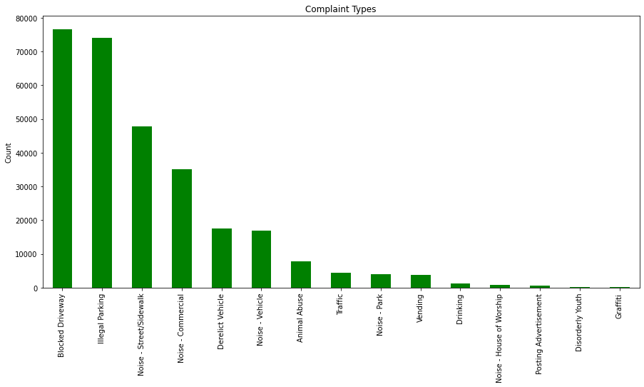

```python
# Plotting the complaint types
df['Complaint Type'].value_counts().plot(kind = 'bar', title='Complaint Types', ylabel='Count',color='g', figsize=(15, 7),)
```

##### *Blocked Driveway is the maximum complaint type followed by Illegal Parking, Noise-Street/Sidewalk and Noise-Commercial.*

```python
# Descriptors
df['Descriptor'].value_counts()
```

```
Loud Music/Party                  60444
No Access                         56725
Posted Parking Sign Violation     22103
Loud Talking                      21254
Partial Access                    19951
With License Plate                17506
Blocked Hydrant                   15837
Commercial Overnight Parking      11908
Car/Truck Music                   11114
Blocked Sidewalk                  10930
Double Parked Blocking Traffic     5558
Double Parked Blocking Vehicle     4147
Engine Idling                      4134
Banging/Pounding                   4090
Neglected                          3771
Car/Truck Horn                     3477
Congestion/Gridlock                2736
In Prohibited Area                 2017
Other (complaint details)          1961
Unlicensed                         1756
Overnight Commercial Storage       1746
Unauthorized Bus Layover           1333
Truck Route Violation              1010
In Public                           923
Tortured                            849
Vehicle                             587
Chained                             534
Detached Trailer                    459
No Shelter                          381
Chronic Stoplight Violation         280
Underage - Licensed Est             270
Chronic Speeding                    266
In Car                              248
Playing in Unsuitable Place         245
Drag Racing                         174
Loud Television                      93
Police Report Requested              90
After Hours - Licensed Est           77
Building                             60
Nuisance/Truant                      40
Police Report Not Requested          23
Name: Descriptor, dtype: int64
```

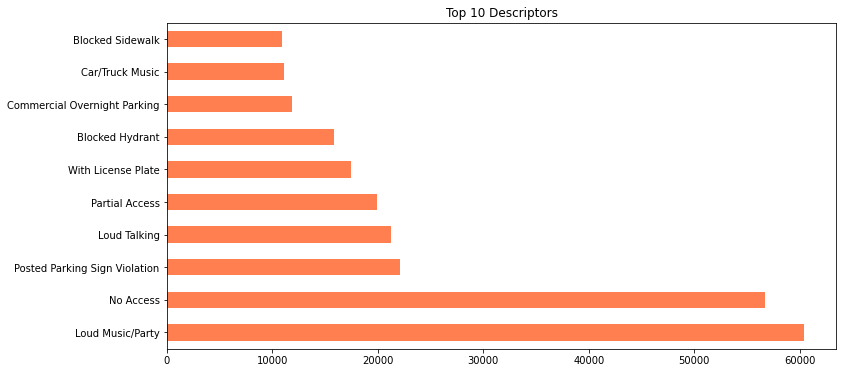

```python
# Plotting top 10 Descriptors
df['Descriptor'].value_counts().head(10).plot(kind='barh',figsize=(12,6), title='Top 10 Descriptors', color='Coral')
```

##### *Loud Music/Party is the maximum descriptor for the complaints followed by No Access, Posted Parking Sign Violation and Loud Taking.*

```python
# Top 10 Location Type
df['Location Type'].value_counts().head(10)
```

```
Street/Sidewalk               242765
Store/Commercial               19425
Club/Bar/Restaurant            17172
Residential Building/House      5753
Park/Playground                 4246
House of Worship                 920
Residential Building             226
Highway                          196
Parking Lot                      116
House and Store                   93
Name: Location Type, dtype: int64
```

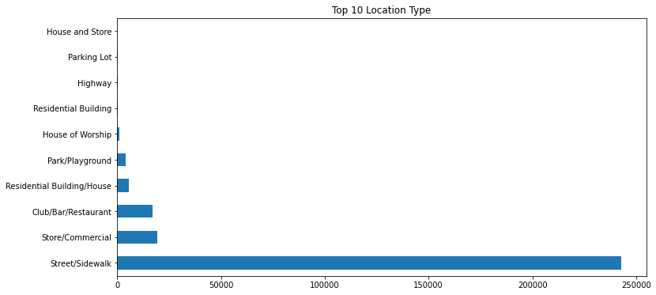

```python
# Plotting Top 10 Location Type
df['Location Type'].value_counts().head(10).plot(kind='barh', figsize=(12, 6), title='Top 10 Location Type')
```

##### *Location Type of Street/Sidewalk is a lot more than any other members of its category.*

```python
# City
df['City'].value_counts().head(10)
```

```
BROOKLYN         96858
NEW YORK         61935
BRONX            40216
STATEN ISLAND    12211
JAMAICA           7155
ASTORIA           6254
FLUSHING          5916
RIDGEWOOD         5124
CORONA            4265
WOODSIDE          3493
Name: City, dtype: int64
```

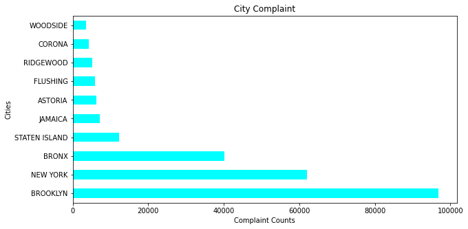

```python
# Plotting the Cities
df['City'].value_counts().head(10).plot(kind='barh', figsize=(10, 5), title='City Complaint', color= 'cyan', ylabel='Cities')
plt.xlabel('Complaint Counts')
```

##### *So most complaints are from BROOKLYN followed New York, Bronx and Staten Island in City wise.*

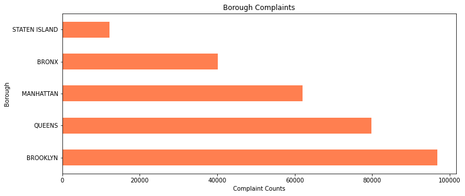

```python
# Borough
df['Borough'].value_counts().head(10).plot(kind='barh', figsize=(12, 5), title='Borough Complaints', color= 'Coral', ylabel='Borough')
plt.xlabel('Complaint Counts')
```

##### *So most complaints are from BROOKLYN followed Queens, Manhattan, Bronx and Staten Island in Borough wise.*

```python
# We analyzied only one column. now lets analyze Borough and Complaint types.
# Borough per Complaint Type.
# Top Complaints
Top_6_comp = df['Complaint Type'].value_counts()[:6].keys()
Top_6_comp
```

```
Index(['Blocked Driveway', 'Illegal Parking', 'Noise - Street/Sidewalk',
       'Noise - Commercial', 'Derelict Vehicle', 'Noise - Vehicle'],
      dtype='object')
```

```python
# Borough per Complaints
Borough_comp = df.groupby(['Borough', 'Complaint Type']).size().unstack()
Borough_comp = Borough_comp[Top_6_comp]
Borough_comp
```

| Complaint Type Borough | Blocked Driveway | Illegal Parking | Noise - Street/Sidewalk | Noise - Commercial | Derelict Vehicle | Noise - Vehicle |
| --- | --- | --- | --- | --- | --- | --- |
| BRONX | 12740 | 7829 | 8864 | 2431 | 1948 | 3385 |
| BROOKLYN | 28119 | 27386 | 13315 | 11451 | 5164 | 5145 |
| MANHATTAN | 2055 | 11981 | 20362 | 14528 | 530 | 5374 |
| QUEENS | 31621 | 21944 | 4391 | 6057 | 8102 | 2608 |
| STATEN ISLAND | 2141 | 4881 | 815 | 677 | 1762 | 356 |

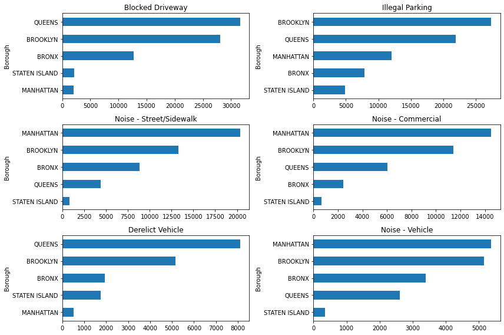

```python
# Plotting Borough per Complaint Type
col_number = 2
row_number = 3
fig, axes = plt.subplots(row_number,col_number, figsize=(12,8))

for i, (label,col) in enumerate(Borough_comp.iteritems()):
    ax = axes[int(i/col_number), i%col_number]
    col = col.sort_values(ascending=True)[:15]
    col.plot(kind='barh', ax=ax,)
    ax.set_title(label)

plt.tight_layout()
```

```python
# Similarly for Complaints per Borough.
Top_borough = df['Borough'].value_counts().keys()

comp_per_borough = df.groupby(['Complaint Type', 'Borough']).size().unstack()
comp_per_borough = comp_per_borough[Top_borough]
comp_per_borough
```

| Borough Complaint Type | BROOKLYN | QUEENS | MANHATTAN | BRONX | STATEN ISLAND |
| --- | --- | --- | --- | --- | --- |
| Animal Abuse | 2390 | 1874 | 1511 | 1412 | 557 |
| Blocked Driveway | 28119 | 31621 | 2055 | 12740 | 2141 |
| Derelict Vehicle | 5164 | 8102 | 530 | 1948 | 1762 |
| Disorderly Youth | 72 | 59 | 68 | 63 | 23 |
| Drinking | 257 | 357 | 294 | 187 | 175 |
| Graffiti | 43 | 37 | 22 | 9 | 2 |
| Illegal Parking | 27386 | 21944 | 11981 | 7829 | 4881 |
| Noise - Commercial | 11451 | 6057 | 14528 | 2431 | 677 |
| Noise - House of Worship | 338 | 297 | 189 | 79 | 17 |
| Noise - Park | 1537 | 634 | 1167 | 522 | 67 |
| Noise - Street/Sidewalk | 13315 | 4391 | 20362 | 8864 | 815 |
| Noise - Vehicle | 5145 | 2608 | 5374 | 3385 | 356 |
| Posting Advertisement | 45 | 30 | 41 | 16 | 515 |
| Traffic | 1082 | 1302 | 1531 | 355 | 196 |
| Vending | 514 | 477 | 2380 | 377 | 25 |

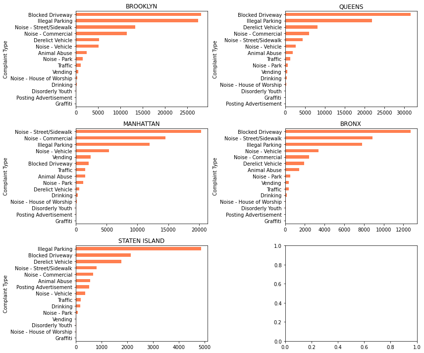

```python
# Plotting Complaints per Borough
col_number = 2
row_number = 3
fig, axes = plt.subplots(row_number,col_number, figsize=(12,10))

for i, (label,col) in enumerate(comp_per_borough.iteritems()):
    ax = axes[int(i/col_number), i%col_number]
    col = col.sort_values(ascending=True)[:15]
    col.plot(kind='barh', ax=ax, color='coral')
    ax.set_title(label)

plt.tight_layout()
```

##### ANALYSIS: - BROOKLYN, QUEENS and BRONX has most complaints of Blocked Driveway. - MANHATTAN has most complaints of Noise - Street/Sidewalk. - STATEN ISLAND has most complaints of Illegal Parking.

#### 4. Order the complaint types based on the average ‘Request_Closing_Time’, grouping them for different locations.

Request_Closing_Time has format of days-hour-minute-seconds. So calculating or operating can be a tedious process, to make a work easier will first convert Request_Closing_Time from days to number of hours. This will make the data calculation or operation easier.

Since, converting 2:30 hours to timedelta64[h] will give 2 hours, hence we will add 1 and will say that this particular request was closed within 3 hours. Then will find out the mean and standard distribution of the data.

```python
# Creating a column Request_Closing_Time_in_Hours for time in Hours
# And will say that the said complaint has been closed under x hours
df['Request_Closing_Time_in_Hours'] = df['Request_Closing_Time'].astype('timedelta64[h]')+1

# viewing the Two columns side by side for first 20 entries
df[['Request_Closing_Time', 'Request_Closing_Time_in_Hours']].head(10)
```

|  | Request_Closing_Time | Request_Closing_Time_in_Hours |
| --- | --- | --- |
| 0 | 0 days 00:55:15 | 1.0 |
| 1 | 0 days 01:26:16 | 2.0 |
| 2 | 0 days 04:51:31 | 5.0 |
| 3 | 0 days 07:45:14 | 8.0 |
| 4 | 0 days 03:27:02 | 4.0 |
| 5 | 0 days 01:53:30 | 2.0 |
| 6 | 0 days 01:57:28 | 2.0 |
| 7 | 0 days 01:47:55 | 2.0 |
| 8 | 0 days 08:33:02 | 9.0 |
| 9 | 0 days 01:23:02 | 2.0 |

```python
#  Ordering the complaint types based on the average ‘Request_Closing_Time’ in Hours, grouping them for different locations.
data_avg_time_in_hrs = df.groupby(['City', 'Complaint Type'])['Request_Closing_Time_in_Hours'].mean()
data_avg_time_in_hrs.head(10)
```

```
City     Complaint Type
ARVERNE  Animal Abuse                2.631579
         Blocked Driveway            3.028571
         Derelict Vehicle            3.407407
         Disorderly Youth            4.000000
         Drinking                    1.000000
         Graffiti                    2.000000
         Illegal Parking             2.827586
         Noise - Commercial          3.000000
         Noise - House of Worship    2.090909
         Noise - Park                1.500000
Name: Request_Closing_Time_in_Hours, dtype: float64
```

```python
# Creating a column Request_Closing_Time_in_Seconds for time in seconds
df['Request_Closing_Time_in_Seconds'] = df['Request_Closing_Time'].astype('timedelta64[s]')

# Viewing the Three columns side by side
df[['Request_Closing_Time', 'Request_Closing_Time_in_Hours','Request_Closing_Time_in_Seconds']].head()
```

|  | Request_Closing_Time | Request_Closing_Time_in_Hours | Request_Closing_Time_in_Seconds |
| --- | --- | --- | --- |
| 0 | 0 days 00:55:15 | 1.0 | 3315.0 |
| 1 | 0 days 01:26:16 | 2.0 | 5176.0 |
| 2 | 0 days 04:51:31 | 5.0 | 17491.0 |
| 3 | 0 days 07:45:14 | 8.0 | 27914.0 |
| 4 | 0 days 03:27:02 | 4.0 | 12422.0 |

```python
#  Order the complaint types based on the average ‘Request_Closing_Time’ in seconds, grouping them for different locations.
data_avg_in_seconds = df.groupby(['City', 'Complaint Type']).Request_Closing_Time_in_Seconds.mean()
data_avg_in_seconds.head(10)
```

```
City     Complaint Type
ARVERNE  Animal Abuse                 7753.052632
         Blocked Driveway             9093.485714
         Derelict Vehicle            10685.592593
         Disorderly Youth            12928.500000
         Drinking                      859.000000
         Graffiti                     5520.000000
         Illegal Parking              8338.913793
         Noise - Commercial           8234.000000
         Noise - House of Worship     5623.909091
         Noise - Park                 4620.000000
Name: Request_Closing_Time_in_Seconds, dtype: float64
```

```python
# lets analyze the Request_Closing_Time
df['Request_Closing_Time'].describe()
```

```
count                       291107
mean     0 days 04:18:32.132665995
std      0 days 06:03:45.509089128
min                0 days 00:01:00
25%                0 days 01:16:30
50%                0 days 02:42:38
75%                0 days 05:20:24
max               24 days 16:52:22
Name: Request_Closing_Time, dtype: object
```

```python
# Taking the Mean and Standard
mean_hrs = df['Request_Closing_Time_in_Hours'].mean()
std_hrs = df['Request_Closing_Time_in_Hours'].std()

mean_seconds = df['Request_Closing_Time_in_Seconds'].mean()
std_seconds = df['Request_Closing_Time_in_Seconds'].std()

print('The mean hours is {0:.2f} hours and mean Secondsis {1:.2f} seconds'.format(mean_hrs, mean_seconds))
print('The standard hours is {0:.2f} hours and standard Seconds is {1:.2f} seconds'.format(std_hrs, std_seconds))
```

```
The mean hours is 4.82 hours and mean Secondsis 15512.13 seconds
The standard hours is 6.06 hours and standard Seconds is 21825.51 seconds
```

Now will analyse Complaint Types column on the basis of Months by refering to Created Date.

```python
# for analyzing on the basis of month will need to separate months from Created Date column
df['Year-Month'] = df['Created Date'].apply(lambda x:datetime.datetime.strftime(x, '%Y-%m'))
```

```python
# viewing the months that we have in our dataset
df['Year-Month'].unique()
```

```
array(['2015-12', '2015-11', '2015-10', '2015-09', '2015-08', '2015-07',
       '2015-06', '2015-05', '2015-04', '2015-03'], dtype=object)
```

We have incident complaints from March to December.

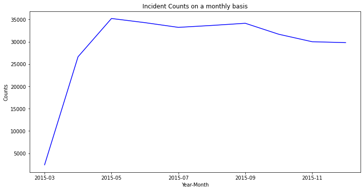

```python
# Plotting the month column
# df['Year-Month'].value_counts().plot()
monthly_incidents =  df.groupby('Year-Month').size().plot(figsize=(12,6),
                                                          title='Incident Counts on a monthly basis', color='Blue', ylabel='Counts')
```

##### January and Ferbruary does not have any Complaints? Looks like nobody wants to go out in cold weather....😉 We don't have any complaints from January and Ferbruary in our dataset because we might have eliminated them as Null Values earlier.

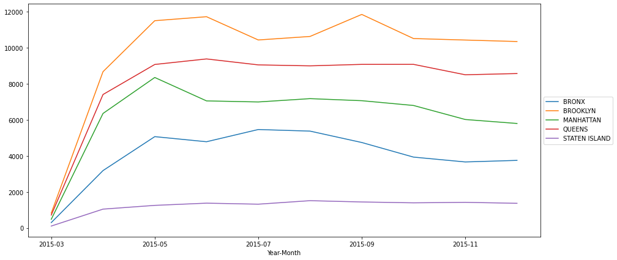

```python
# Plotting Borough on the basis of Year-Month
df.groupby(['Year-Month','Borough']).size().unstack().plot(figsize=(15,7))
plt.legend(loc='center left', bbox_to_anchor=(1.0, 0.5))
```

##### *BROOKLYN raised most cases all over and most of them were raised in MAY-JUNE and SEPTEMBER.*

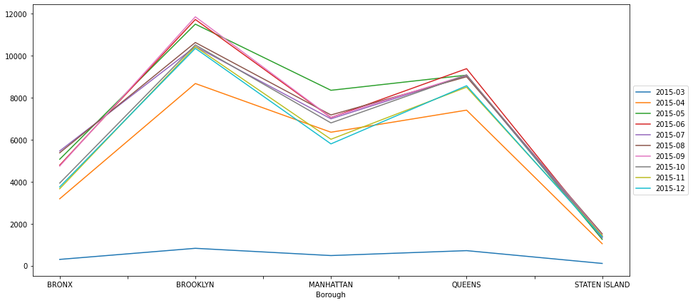

```python
# Plotting Year-Month on the basis of Borough
df.groupby(['Borough', 'Year-Month']).size().unstack().plot(figsize=(15,7))
plt.legend(loc='center left', bbox_to_anchor=(1.0, 0.5))
```

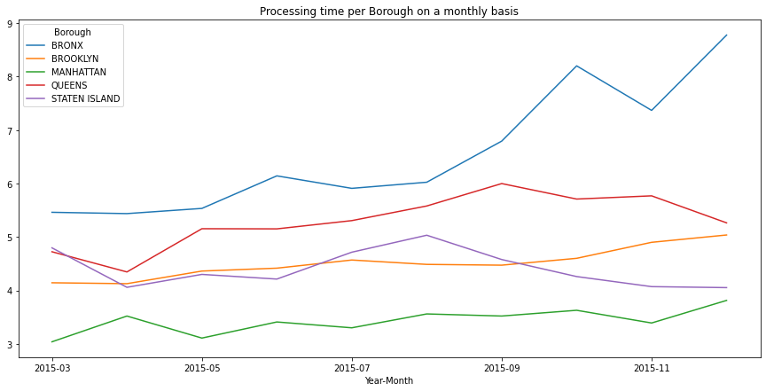

```python
# Processing time per Borough on a monthly basis
df.groupby(['Year-Month','Borough'])['Request_Closing_Time_in_Hours'].mean().unstack().plot(figsize=(15,7),
                                                                        title='Processing time per Borough on a monthly basis');
```

#### 5. Perform a statistical test for the following: Please note: For the below statements you need to state the Null and Alternate and then provide a statistical test to accept or reject the Null Hypothesis along with the corresponding ‘p-value’.

```python
# A. Whether the average response time across complaint types is similar or not (overall)
# B. Are the type of complaint or service requested and location related?
```

```python
# viewing the columns
df.columns
```

```
Index(['Unique Key', 'Created Date', 'Closed Date', 'Agency', 'Complaint Type',
       'Descriptor', 'Location Type', 'Incident Zip', 'City',
       'Resolution Description', 'Borough', 'Latitude', 'Longitude',
       'Request_Closing_Time', 'Request_Closing_Time_in_Hours',
       'Request_Closing_Time_in_Seconds', 'Year-Month'],
      dtype='object')
```

```python
# lets see the average response time in seconds for different complaint types
avg_response_time = df.groupby(['Complaint Type']).Request_Closing_Time_in_Seconds.mean().sort_values(ascending=True)
avg_response_time
```

```
Complaint Type
Posting Advertisement        7113.582689
Noise - Commercial          11294.078335
Noise - House of Worship    11519.116304
Noise - Park                12249.610644
Noise - Street/Sidewalk     12392.210610
Traffic                     12426.186968
Disorderly Youth            12847.733333
Noise - Vehicle             12953.606711
Drinking                    13885.939370
Vending                     14442.301617
Illegal Parking             16140.427217
Blocked Driveway            17056.511751
Animal Abuse                18786.728951
Graffiti                    25744.504425
Derelict Vehicle            26450.507426
Name: Request_Closing_Time_in_Seconds, dtype: float64
```

**Null Hypothesis** -->> Average response time across complaint types is similar(overall).  
**Alternate Hypothesis** -->> Average response time across complaint types is not similar(overall).  
-- We can say that for overall case NULL HYPOTHESIS is rejected as the Average Response Time in Seconds for different complaint types is different.

##### Testing Hypothesis

*Below will conduct ANOVA (Analysis of Variance) test for top 5 type of complaints.*

*For a 95% of confidence interval we choose our alpha as 0.05 for 5%.*

*Alpha(0.05) is the critical p-value, if our calculated p-value is less than alpha, it will give us strong evidence to reject Null* Hypothesis.

*if p < alpha(0.05) : Reject Null Hypothesis, Average response time for all the complaints type is not same.*

*if p > alpha(0.05) : Fail to reject Null Hypothesis, Average response time for all the complaints type is same.*

```python
# To calculate the p-value log of time taken to close the complaint per complaint is taken
data = {}
for complaint in df['Complaint Type'].unique():
    data[complaint] = np.log(df[df['Complaint Type']==complaint]['Request_Closing_Time_in_Seconds'])
```

```python
data.keys()
```

```
dict_keys(['Noise - Street/Sidewalk', 'Blocked Driveway', 'Illegal Parking', 'Derelict Vehicle', 'Noise - Commercial', 'Noise - House of Worship', 'Posting Advertisement', 'Noise - Vehicle', 'Animal Abuse', 'Vending', 'Traffic', 'Drinking', 'Noise - Park', 'Graffiti', 'Disorderly Youth'])
```

```python
for complaint in data.keys():
    print(data[complaint].std())
```

```
1.1029853481161118
0.975983533136447
1.0775935064583295
1.2579717580716778
1.088985189191197
1.176476920342657
1.2223658746794284
1.0766368282265082
1.043993830970647
1.1124255292109806
1.1837660579555334
1.0462752311468755
1.119443436237754
1.0644915295126964
1.0383245818152775
```

```python
# importing f_oneway from scipy.stats library
from scipy.stats import f_oneway

# taking top 5 complaints
stat, p = f_oneway(data['Blocked Driveway'], data['Illegal Parking'], data['Noise - Street/Sidewalk'],
                   data['Derelict Vehicle'], data['Noise - Commercial'])
print('Statistics= %.3f, p = %.3f' % (stat, p))

# interpret
alpha = 0.05
if p > alpha:
    print('Same distributions (fail to reject H0)')
else:
    print('We have Different distributions (reject H0)')
```

```
Statistics= 2452.471, p = 0.000
We have Different distributions (reject H0)
```

As our p-value is quite low , hence it is being converted to 0.0  
Since our p-value is lower than our critical p-value, we will conclude that we have enough evidence to reject our Null Hypothesis and that is:  
Average response time for all the complaints type is not same.

**For relation between Complaint Type and Location**  
will use Crosstab and Chi-square Test.

```python
# Getting crosstab from Pandas
city_type = pd.crosstab(df['City'], df['Complaint Type'])
```

```python
# Viewing first 5 entries of city_type
city_type.head()
```

| Complaint Type City | Animal Abuse | Blocked Driveway | Derelict Vehicle | Disorderly Youth | Drinking | Graffiti | Illegal Parking | Noise - Commercial | Noise - House of Worship | Noise - Park | Noise - Street/Sidewalk | Noise - Vehicle | Posting Advertisement | Traffic | Vending |
| --- | --- | --- | --- | --- | --- | --- | --- | --- | --- | --- | --- | --- | --- | --- | --- |
| ARVERNE | 38 | 35 | 27 | 2 | 1 | 1 | 58 | 2 | 11 | 2 | 29 | 7 | 0 | 0 | 1 |
| ASTORIA | 125 | 2618 | 351 | 3 | 35 | 4 | 1065 | 1282 | 19 | 61 | 385 | 204 | 1 | 47 | 54 |
| Astoria | 0 | 116 | 12 | 0 | 0 | 0 | 213 | 261 | 0 | 0 | 114 | 0 | 0 | 0 | 0 |
| BAYSIDE | 37 | 376 | 198 | 1 | 1 | 3 | 511 | 40 | 2 | 3 | 15 | 16 | 0 | 9 | 2 |
| BELLEROSE | 7 | 95 | 89 | 2 | 1 | 0 | 105 | 37 | 1 | 1 | 13 | 10 | 1 | 7 | 0 |

**Now will do Chi-square Test**

```python
# Contigency table
table = city_type
# table -->> The contingency table. The table contains the observed frequencies (i.e. number of occurrences) in each category.
# stat -->> chi2 or Test Statistic
# p -->> The p-value of the Test
# dof -->> Degrees of Freedom
# expected -->> The expected frequencies, based on the marginal sums of the table.
stat, p, dof, expected = chi2_contingency(table)
```

```python
print('The Degrees of Freedom are : {}'. format(dof))
print('The P-Value of the Testing is {}: '.format(p))
print('Expected values : \n')
print(expected)
```

[output not shown]

[output cut: 161 more lines]

[output not shown]

```python
# Interpreting test statistics
prob = 0.95 # as aplha is considered 0.05
critical_value = chi2.ppf(prob, dof)
critical_value
```

```
791.8799091140163
```

```python
print('Probability = {}, Critical Value = {}, Test statistic = {}'.format(prob, critical_value, stat))
print()
if abs(stat) >= critical_value:
    print('Dependent (Reject H0 or Null Hypothesis)')
else:
    print('Independent (Failed to reject Null Hypothesis)')


# interpreting the P-Value
alpha = 1 - prob
print('Significance : %.3f, P-Value : %.2f'%(alpha, p))
if p <= alpha:
    print('Dependent (Reject H0 or Null Hypothesis)')
else:
    print('Independent (Failed to reject Null Hypothesis)')
```

```
Probability = 0.95, Critical Value = 791.8799091140163, Test statistic = 105247.14233091185

Dependent (Reject H0 or Null Hypothesis)
Significance : 0.050, P-Value : 0.00
Dependent (Reject H0 or Null Hypothesis)
```

## --------------------------------------------------------------------------------------------------------------------------------